# Análisis de regímenes de inundación — Bifurcación hidráulica en HEC-RAS

Caso de estudio: **Río Besaya — Corrales de Buelna**

**Flujo del análisis:**

1. Cargar resultados y clasificar regímenes (GMM de 2 componentes)
2. Verificar que Manning **no** predice el régimen (t-test / Spearman)
3. Localizar la zona exclusiva del régimen ALTO
4. Identificar la silla topográfica (punto mínimo de la barrera entre zonas)
5. Figura de publicación — bifurcación hidráulica

## Rutas — ajustar según el entorno

## 1 · Cargar resultados y clasificar regímenes (GMM)

Se ajusta una Mezcla Gaussiana de 2 componentes sobre el área inundada de HEC-RAS. El umbral entre regímenes lo determina el modelo, sin elegirlo a mano.

```
Régimen BAJO  (label=0): n=  97  área=0.5769 km²
Régimen ALTO  (label=1): n= 898  área=0.7004 km²

Medias GMM:  [np.float64(0.624), np.float64(0.7013)]
Stds  GMM:   [np.float64(0.0489), np.float64(0.0535)]
```

## 2 · Manning **no** predice el régimen (t-test y Spearman)

Si los dos regímenes fueran causados por los valores de Manning, algún coeficiente debería mostrar diferencias estadísticamente significativas entre grupos.

```
Ningún coeficiente es significativo → Manning NO separa los regímenes
```

| Uso del suelo | Media BAJO | Media ALTO | t | p (t-test) | ρ (Spearman) | p (Spearman) |
| --- | --- | --- | --- | --- | --- | --- |
| Trees | 0.1616 | 0.1654 | -0.7613 | 0.4467 | 0.0270 | 0.3943 |
| Dense vegetation | 0.0979 | 0.0982 | -0.1280 | 0.8982 | 0.0021 | 0.9467 |
| Urban vegetation | 0.0864 | 0.0880 | -0.5154 | 0.6064 | 0.0172 | 0.5871 |
| Infrastructure | 0.0152 | 0.0151 | 0.1464 | 0.8836 | -0.0031 | 0.9227 |
| Sparse vegetation | 0.0496 | 0.0506 | -0.4609 | 0.6449 | 0.0093 | 0.7699 |
| Residential | 0.0146 | 0.0146 | 0.0335 | 0.9733 | -0.0052 | 0.8686 |
| Industrial | 0.0182 | 0.0183 | -0.2801 | 0.7794 | -0.0001 | 0.9979 |
| River | 0.0404 | 0.0405 | -0.0401 | 0.9680 | -0.0008 | 0.9801 |
| Brushland | 0.0763 | 0.0772 | -0.3545 | 0.7231 | 0.0226 | 0.4771 |

## 3 · SFINCS área sí correlaciona con el régimen HEC-RAS

Aunque Manning individual no predice el régimen, la respuesta integrada de SFINCS (que captura el balance energético total) sí lo hace. Esto confirma que el régimen depende de la energía del flujo, no de un único uso del suelo.

```
SFINCS área   vs régimen HR:  ρ=+0.363  p=2.22e-32
HR manning_mean vs régimen:   ρ=+0.069  p=3.00e-02
```

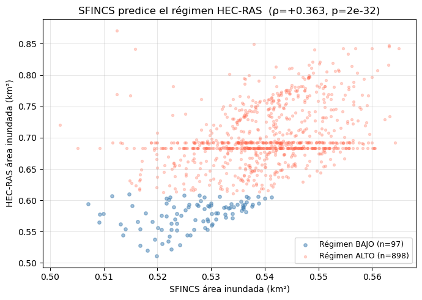

## 4 · Localizar la zona exclusiva del régimen ALTO y la silla topográfica

Se construyen mapas de frecuencia de inundación para cada régimen.  
La **zona exclusiva del régimen ALTO** es la diferencia espacial entre ambos mapas.  
La **silla topográfica** es el punto de mínima elevación en el corredor entre la zona permanentemente inundada (régimen BAJO) y la zona exclusiva.

```
Construyendo mapas de frecuencia...
```

[output not shown]

```
Silla topográfica (punto mínimo de la barrera):
  Elevación: 60.05 m s.n.m.
  X = 413230,  Y = 4793166  (EPSG:25830)

El umbral de desbordamiento hacia la zona secundaria está en ~60.0 m.

Elevación de la zona exclusiva regímen ALTO (P5-P95): 62.5 – 78.0 m
```

## 5 · Figura de publicación — Bifurcación hidráulica

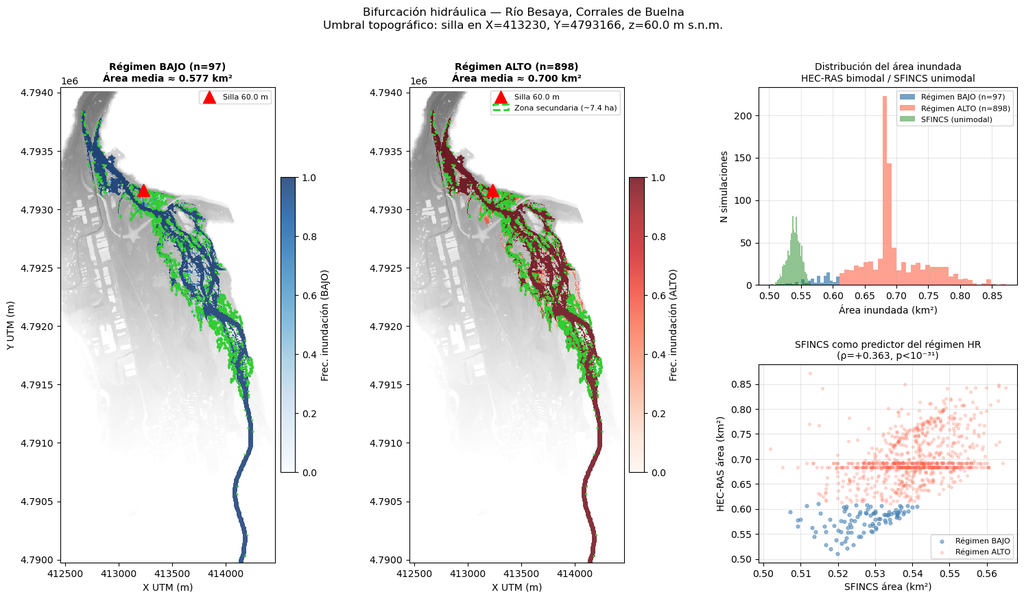

```
Guardado: hydraulic_bifurcation.png
```

## 6 · Elevación del perfil transversal en la barrera

El histograma de elevaciones del corredor entre zonas permite ver a qué cotas se encuentra la barrera topográfica.

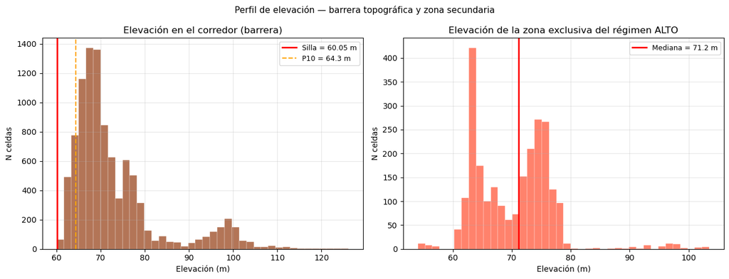

```
Resumen barrera:
  Silla (mínimo de la barrera): 60.05 m
  P10 corredor:                 64.31 m
  P90 corredor:                 90.80 m
  Zona secundaria mediana:      71.16 m
```

## 7 · Interpretación y conclusiones

### ¿Por qué dos regímenes?

Existe una **barrera topográfica** entre el cauce principal del Besaya y una llanura lateral secundaria. El punto más bajo de esta barrera (la silla) se encuentra a **~60 m s.n.m.**

### ¿Por qué HEC-RAS lo capta y SFINCS no?

| Modelo | Ecuaciones | Respuesta al umbral |
| --- | --- | --- |
| **HEC-RAS** | Saint-Venant 2D completo (con advección) | Discontinua — bimodal |
| **SFINCS** | Inercial simplificada (sin advección) | Continua — unimodal |

Los términos advectivos ρu·∇u permiten que HEC-RAS transfiera impulso hidráulico hacia el punto de silla. Cerca del umbral, pequeñas variaciones de energía (causadas por la rugosidad, la profundidad, o la velocidad aguas arriba) determinan si el flujo supera o no la barrera. La respuesta es **discontinua**.

SFINCS, sin esos términos, no acumula impulso hacia la silla → la respuesta es suave y la transición no genera bimodalidad.

### ¿Es un artefacto numérico?

No. La correlación entre el área de SFINCS y el régimen de HEC-RAS (ρ=+0.36, p<10⁻³¹) confirma que hay una señal física real. Manning individual no predice el régimen (todos los p>0.35) porque el umbral es sensible a la **energía integrada del flujo**, no a un uso del suelo concreto.

### Implicación para el paper

> La distribución bimodal del área inundada en HEC-RAS no es un defecto del análisis, sino una consecuencia de la correcta representación de un umbral topográfico real mediante ecuaciones de Saint-Venant completas. SFINCS no puede reproducirlo por diseño. Esto añade una tercera fuente de incertidumbre — la **estructura de la distribución de respuesta** — que solo emerge al comparar modelos con diferentes formulaciones.